# ST661: Assignment 4

Nishant kumar

02 December, 2019

#### Question 1

The above packages are pre-installed on the Logic House computers and on our Rstudio server. 1. This question involves a dataset which gives a record of every men’s singles match played in Wimbledon in 2015. Type in the following to load the data called wim. a.Use mutate (from dplyr) to add a new variable which is the difference in heights of the winner and loser. Use ggplot to draw a histogram of the new variable.

```r
load("h4data")
library(tidyverse)
library(dplyr)
p1<-mutate(wim,diffrence=wim$winner_ht-wim$loser_ht)
head(p1)
```

```
## # A tibble: 6 x 50
##   tourney_id tourney_name surface draw_size tourney_level tourney_date
##   <chr>      <chr>        <chr>       <int> <chr>                <int>
## 1 2015-540   Wimbledon    Grass         128 G                 20150629
## 2 2015-540   Wimbledon    Grass         128 G                 20150629
## 3 2015-540   Wimbledon    Grass         128 G                 20150629
## 4 2015-540   Wimbledon    Grass         128 G                 20150629
## 5 2015-540   Wimbledon    Grass         128 G                 20150629
## 6 2015-540   Wimbledon    Grass         128 G                 20150629
## # … with 44 more variables: match_num <int>, winner_id <int>,
## #   winner_seed <int>, winner_entry <chr>, winner_name <chr>,
## #   winner_hand <chr>, winner_ht <int>, winner_ioc <chr>,
## #   winner_age <dbl>, winner_rank <int>, winner_rank_points <int>,
## #   loser_id <int>, loser_seed <int>, loser_entry <chr>, loser_name <chr>,
## #   loser_hand <chr>, loser_ht <int>, loser_ioc <chr>, loser_age <dbl>,
## #   loser_rank <int>, loser_rank_points <int>, score <chr>, best_of <int>,
## #   round <chr>, minutes <int>, w_ace <int>, w_df <int>, w_svpt <int>,
## #   w_1stIn <int>, w_1stWon <int>, w_2ndWon <int>, w_SvGms <int>,
## #   w_bpSaved <int>, w_bpFaced <int>, l_ace <int>, l_df <int>,
## #   l_svpt <int>, l_1stIn <int>, l_1stWon <int>, l_2ndWon <int>,
## #   l_SvGms <int>, l_bpSaved <int>, l_bpFaced <int>, diffrence <int>
```

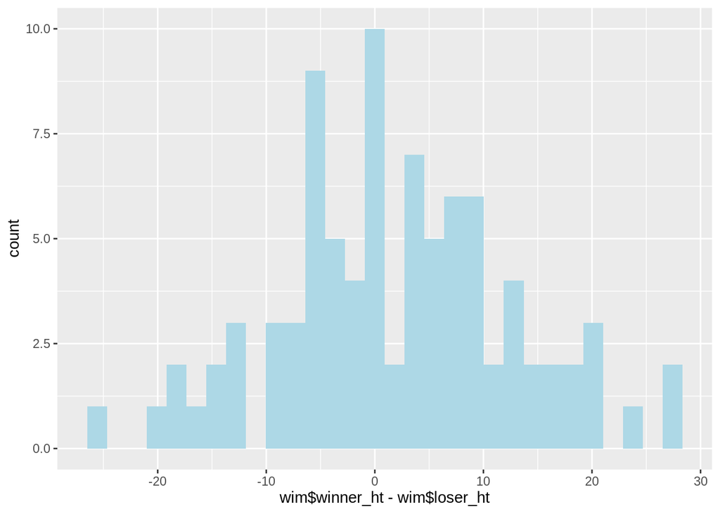

```r
ggplot(wim, aes(x=wim$winner_ht-wim$loser_ht)) +
  geom_histogram(fill="lightblue")
```

b.Construct a dataset by_player with one row per player, recording also the number of wins, ranking points, height and country of the player. Do this in the following steps: i. Construct a dataset w_wim, containing for each match the intormation name= winner_name, points=winner_rank_points, ht= winner_ht, ioc= winner_ioc, and a new variable wins with a value of 1. Use select and mutate.

```r
w1<-select(wim,name=winner_name,point=winner_rank_points,ht=winner_ht,ioc=winner_ioc)
w_wim<-mutate(w1,wins=1)
w_wim
```

```
## # A tibble: 127 x 5
##    name                  point    ht ioc    wins
##    <chr>                 <int> <int> <chr> <dbl>
##  1 Novak Djokovic        13845   188 SRB       1
##  2 Jarkko Nieminen         564   185 FIN       1
##  3 Pierre Hugues Herbert   353    NA FRA       1
##  4 Bernard Tomic          1355   193 AUS       1
##  5 Leonardo Mayer         1605   188 ARG       1
##  6 Marcel Granollers       715   190 ESP       1
##  7 Marsel Ilhan            647   190 TUR       1
##  8 Kevin Anderson         2090   203 RSA       1
##  9 Marin Cilic            3540   198 CRO       1
## 10 Ricardas Berankis       577   175 LTU       1
## # … with 117 more rows
```

ii.Construct a dataset l_wim, containing for each match the intormation name= loser_name, points=loser_rank_points, ht= loser_ht, ioc= loser_ioc, and a new variable wins with a value of 0.

```r
w2<-select(wim,name=loser_name,point=loser_rank_points,ht=loser_ht,ioc=loser_ioc)
l_wim<-mutate(w2,wins=0)
l_wim
```

```
## # A tibble: 127 x 5
##    name                  point    ht ioc    wins
##    <chr>                 <int> <int> <chr> <dbl>
##  1 Philipp Kohlschreiber  1195   178 GER       0
##  2 Lleyton Hewitt          465   180 AUS       0
##  3 Hyeon Chung             671    NA KOR       0
##  4 Jan Lennard Struff      478    NA GER       0
##  5 Thanasi Kokkinakis      723    NA AUS       0
##  6 Janko Tipsarevic         76   180 SRB       0
##  7 Jerzy Janowicz          975   203 POL       0
##  8 Lucas Pouille           539    NA FRA       0
##  9 Hiroki Moriya           294    NA JPN       0
## 10 Andreas Haider Maurer   857   190 AUT       0
## # … with 117 more rows
```

3. Use rbind to stick w_wim and l_wim together. Call the result wl_wim

```r
wl_wim<-rbind(w_wim,l_wim)
wl_wim
```

```
## # A tibble: 254 x 5
##    name                  point    ht ioc    wins
##    <chr>                 <int> <int> <chr> <dbl>
##  1 Novak Djokovic        13845   188 SRB       1
##  2 Jarkko Nieminen         564   185 FIN       1
##  3 Pierre Hugues Herbert   353    NA FRA       1
##  4 Bernard Tomic          1355   193 AUS       1
##  5 Leonardo Mayer         1605   188 ARG       1
##  6 Marcel Granollers       715   190 ESP       1
##  7 Marsel Ilhan            647   190 TUR       1
##  8 Kevin Anderson         2090   203 RSA       1
##  9 Marin Cilic            3540   198 CRO       1
## 10 Ricardas Berankis       577   175 LTU       1
## # … with 244 more rows
```

4. Use group_by on wl_wim, to group it by name. and summarise the result of the previous step, with wins=sum(wins), points=points[1], ht=ht[1], ioc=ioc[1].

```r
#detach(package:plyr)
by_player<-wl_wim %>%  group_by(name) %>% summarise(wins=sum(wins),point=point[1], ht=ht[1],ioc=ioc[1])
by_player
```

```
## # A tibble: 128 x 5
##    name                   wins point    ht ioc
##    <chr>                 <dbl> <int> <int> <chr>
##  1 Adrian Mannarino          1  1188   183 FRA
##  2 Albert Ramos              1   758   188 ESP
##  3 Alejandro Falla           0   423   185 COL
##  4 Aleksandr Nedovyesov      0   457    NA KAZ
##  5 Alexander Zverev          1   689    NA GER
##  6 Alexandr Dolgopolov       1   740   180 UKR
##  7 Aljaz Bedene              1   688   181 GBR
##  8 Andreas Haider Maurer     0   857   190 AUT
##  9 Andreas Seppi             2  1280   190 ITA
## 10 Andy Murray               5  7450   190 GBR
## # … with 118 more rows
```

c.Calculate the average height for all players in the tournament. Use ggplot to plot player points versus number of wins

```r
mean(na.omit(by_player$ht))
```

```
## [1] 186.65
```

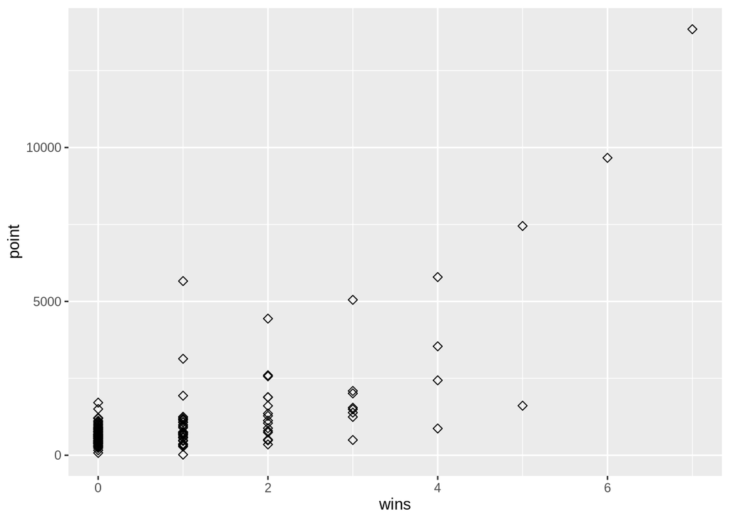

```r
ggplot(by_player, aes(x=wins,y=point)) +
  geom_point(size=2,shape=23)
```

d.Using the dataset by_player, write code to find the names of the tournament winner and the losing finalist. If you did not manage to correctly construct the dataset by_player, do this some other way.

```r
a5<-by_player[order(-by_player$wins),]
a5[c(1,2),]
```

```
## # A tibble: 2 x 5
##   name            wins point    ht ioc
##   <chr>          <dbl> <int> <int> <chr>
## 1 Novak Djokovic     7 13845   188 SRB
## 2 Roger Federer      6  9665   185 SUI
```

e.Calculate the number of wins per country. How many matches were won by Spanish (ESP) players?

```r
a5<-select(by_player,ioc,point,ht,wins)
a6<-a5 %>% group_by(ioc) %>% summarise_each(funs(sum))
a7<-a6 %>% arrange(desc(wins))
a8<-filter(a7,a7$ioc=='ESP')
a8<-select(a8,ioc,wins)
a8
```

```
## # A tibble: 1 x 2
##   ioc    wins
##   <chr> <dbl>
## 1 ESP      11
```

f.Draw a barplot showing the number of wins for the top 10 countries, preferrably in decreasing order by wins

```r
a9<-a7 %>% top_n(10)
a9
```

```
## # A tibble: 10 x 4
##    ioc   point    ht  wins
##    <chr> <int> <int> <dbl>
##  1 FRA   13750    NA    18
##  2 ESP   15066    NA    11
##  3 AUS    7241    NA    10
##  4 SRB   16487   926    10
##  5 SUI   15455   368    10
##  6 GBR    9412    NA     9
##  7 CRO    6005    NA     8
##  8 USA    7148  1315     7
##  9 CAN    5310   389     6
## 10 CZE    7349    NA     5
```

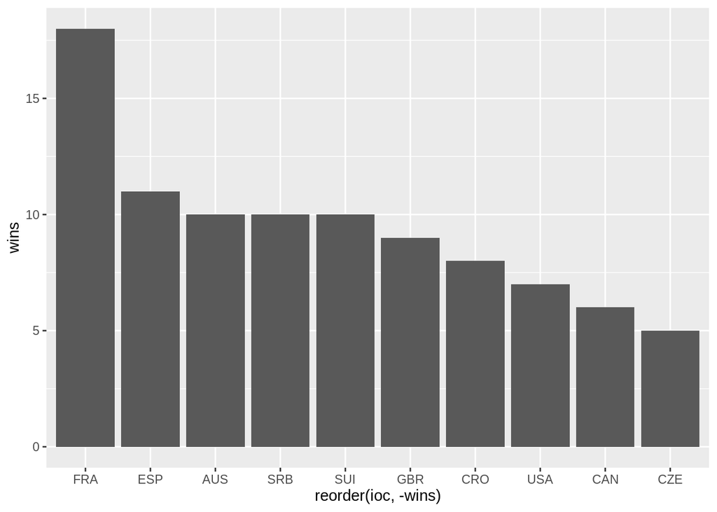

```r
p<-ggplot(data=a9, aes(x=reorder(ioc,-wins), y=wins)) +
  geom_bar(stat="identity")
p
```

######question 2 The website https://cwur.org/2015.php gives world University rankings from 2015 for Universities under various criteria. Read in data for the top40 Universities as below. First convert appropriate variables to numeric. Then answer these questions using dplyr tools and ggplot, in all cases except part (d). d <- read.csv(“top40Univ.csv”, stringsAsFactors = FALSE) a.Summarise the Location (countries) of the universities with counts. Using ggplot, draw a barplot of these location counts

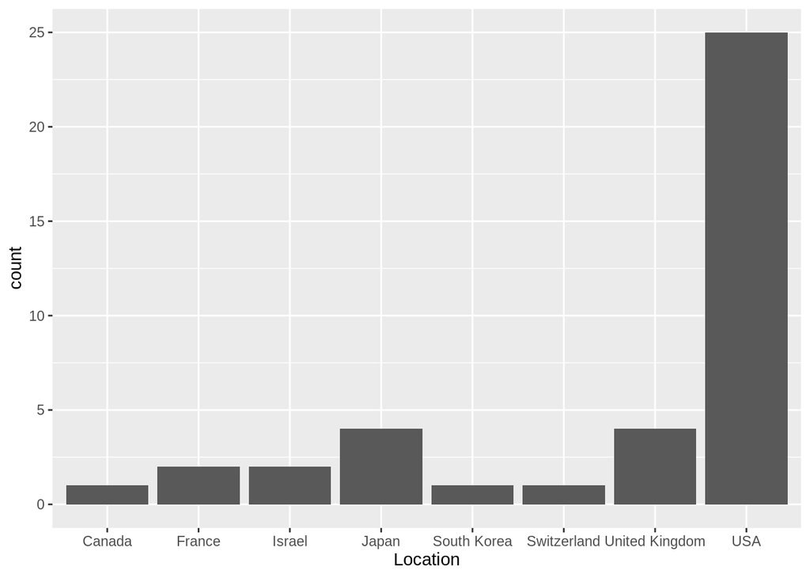

```r
d <- read.csv("top40Univ.csv", stringsAsFactors = FALSE)
d1<-select(d,Location)
d1<-mutate(d1,count=1)
d2<-d1 %>% group_by(Location) %>% summarise_each(funs(sum))
p1<-ggplot(data=d2, aes(x=Location, y=count)) +
  geom_bar(stat="identity")
p1
```

b.Redraw the barplot, with bars in decreasing order. Use fct reorder

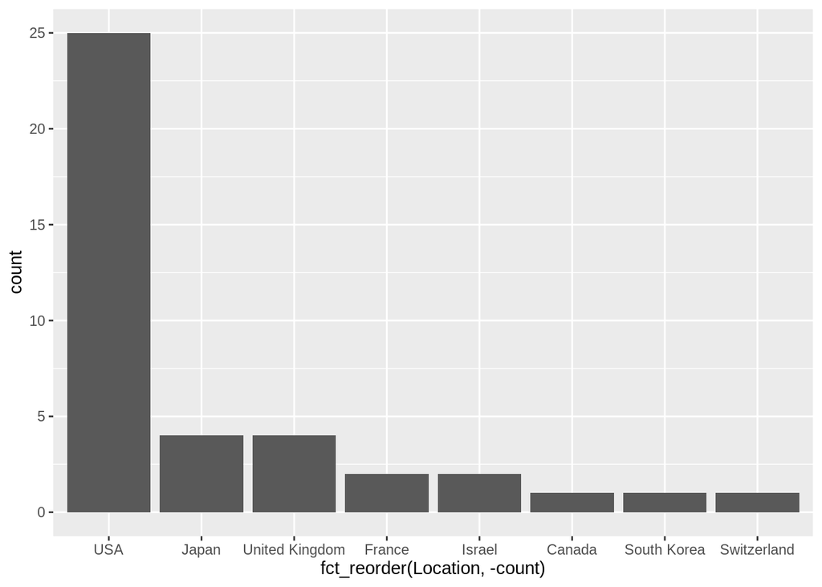

```r
p2<-ggplot(data=d2, aes(x=fct_reorder(Location,-count), y=count)) +
  geom_bar(stat="identity")
p2
```

c.Write a function called top5 that counts the number of values in 1, 2, …5 in a numeric vector, ignoring NAs. Use %in% . Check that the function gives the correct answer on vectors below x1 <- c(NA,10:1) x2 <- c(6,2,8,9,-1,0,4) top5(x1) [1] 5 top5(x2) [1] 2

```r
top5<-function(n){
B = data.frame(C=c(1,2,3,4,5))
A<-n[n%in% B$C]
count=length(A)
return(count)
}
x1 <- c(NA,10:1)
x2 <- c(6,2,8,9,-1,0,4)
top5(x1)
```

```
## [1] 5
```

```r
top5(x2)
```

```
## [1] 2
```

d.Use top5 to calculate for each university, how many of the categories Quality.of.Education, Publications, Influence, Citations, Broad.Impact accorded them a top 5 ranking. Add this information to your dataset. Use base R for your answer.

```r
total<- apply(d[,c(5,6,7,8,9)],1,function(x1){top5(trimws(x1,which = "both"))})
d <- mutate(d,total)
d
```

```
##    World.Rank                                     Institution
## 1           1                              Harvard University
## 2           2                             Stanford University
## 3           3           Massachusetts Institute of Technology
## 4           4                         University of Cambridge
## 5           5                            University of Oxford
## 6           6                             Columbia University
## 7           7              University of California, Berkeley
## 8           8                           University of Chicago
## 9           9                            Princeton University
## 10         10                              Cornell University
## 11         11                                 Yale University
## 12         12              California Institute of Technology
## 13         13                             University of Tokyo
## 14         14                      University of Pennsylvania
```

[output cut: 108 more lines]

e.Here is a dplyr answer to the previous question. Explain how it works. Write code which confirms the columns tc and topcount are identical. Here the base R solution is simpler, in my opinion. Can anyone supply a simpler and better dplyr-based answer? d1 <- d %>% mutate_at(sel, `<=`, 5) %>% select(one_of(sel))%>% mutate(tc = rowSums(., na.rm=T))

```r
sel<-c("Quality.of.Education","Publications","Influence","Citations","Broad.Impact")
d1 <- d %>% mutate_at(sel, `<=`,5) %>%
select(one_of(sel))%>%
mutate(tc = rowSums(., na.rm=T))
d1
```

```
##    Quality.of.Education Publications Influence Citations Broad.Impact tc
## 1                  TRUE         TRUE      TRUE      TRUE         TRUE  5
## 2                 FALSE         TRUE      TRUE      TRUE         TRUE  4
## 3                  TRUE        FALSE      TRUE      TRUE         TRUE  4
## 4                  TRUE        FALSE     FALSE     FALSE        FALSE  1
## 5                 FALSE        FALSE     FALSE     FALSE        FALSE  0
## 6                  TRUE        FALSE     FALSE     FALSE        FALSE  1
## 7                  TRUE        FALSE      TRUE      TRUE        FALSE  3
## 8                  TRUE        FALSE     FALSE     FALSE        FALSE  1
## 9                  TRUE        FALSE     FALSE     FALSE        FALSE  1
## 10                 TRUE        FALSE     FALSE     FALSE        FALSE  1
## 11                 TRUE        FALSE     FALSE     FALSE        FALSE  1
## 12                FALSE        FALSE     FALSE     FALSE        FALSE  0
## 13                 TRUE        FALSE     FALSE     FALSE        FALSE  1
## 14                 TRUE        FALSE     FALSE     FALSE        FALSE  1
```

[output cut: 26 more lines]

```r
# In accordance with the given function is not returning the values similar to total .The issue is with the row 6.While the values are greater than 5,the rows returned value as true.
```

f.Construct a dataset containing the names of Universities who have at least one top 5 ranking.

```r
top5<-d %>% select(Institution)%>% filter (total>=1)
top5
```

```
##                              Institution
## 1                     Harvard University
## 2                    Stanford University
## 3  Massachusetts Institute of Technology
## 4                University of Cambridge
## 5     University of California, Berkeley
## 6                   Princeton University
## 7               Johns Hopkins University
## 8      University of Michigan, Ann Arbor
## 9    University of California, San Diego
## 10    University of Washington - Seattle
## 11                 University of Toronto
```

g.Add a new variable Continent to d, that is NorthAmerica for Universities in USA and Canada, Asia for Japan and South Korea, and Europe otherwise. Suggestion: use ifelse within mutate.

```r
d<-mutate(d,continent= ifelse(grepl("USA",Location),"NorthAmerica",
                    ifelse(grepl("Canada",Location),"NorthAmerica",
                    ifelse(grepl("Japan",Location),"Asia",
                    ifelse(grepl("South Korea",Location),"Asia","Europe")))))
head(d)
```

```
##   World.Rank                           Institution       Location
## 1          1                    Harvard University            USA
## 2          2                   Stanford University            USA
## 3          3 Massachusetts Institute of Technology            USA
## 4          4               University of Cambridge United Kingdom
## 5          5                  University of Oxford United Kingdom
## 6          6                   Columbia University            USA
##   National.Rank Quality.of.Education Publications Influence Citations
## 1             1                    1            1         1         1
## 2             2                    9            5         3         3
## 3             3                    3           15         2         2
## 4             1                    2           11         6        12
## 5             2                    7            7        12         7
## 6             4                   13           13        13        11
##   Broad.Impact  Score total    continent
## 1            1 100.00     5 NorthAmerica
## 2            4  98.66     4 NorthAmerica
## 3            2  97.54     4 NorthAmerica
## 4           13  96.81     1       Europe
## 5            9  96.46     0       Europe
## 6           12  96.14     0 NorthAmerica
```

h.Plot the Citations versus the Broad.Impact rankings,using different colours to distinguish the continents.

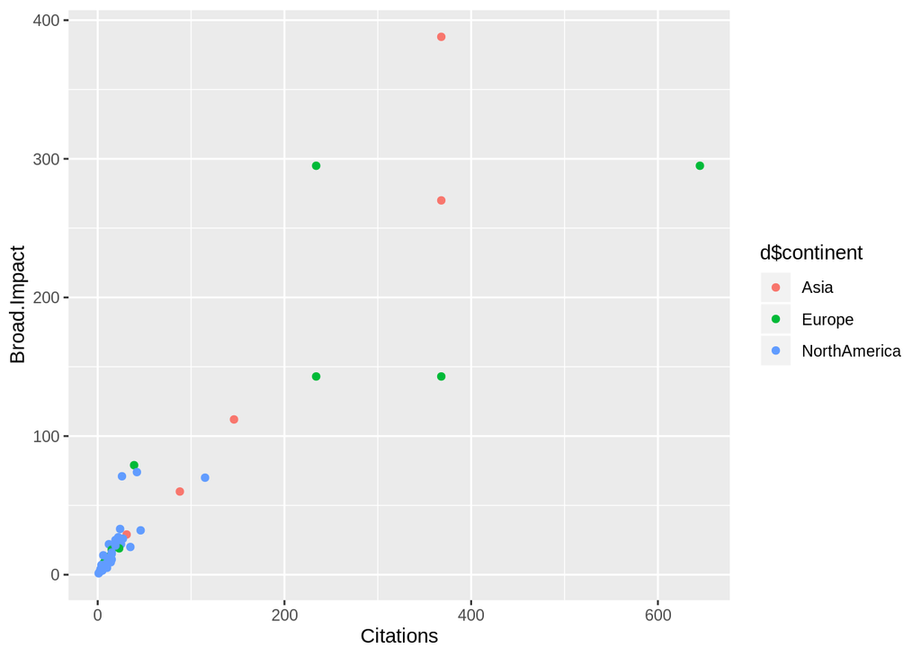

```r
p2<-ggplot(d,aes(Citations,Broad.Impact,colour=d$continent))+geom_point()
p2
```